# Functions_07

```r
rm(list=ls())
```

```r
library(devtools)
```

```r
library(usethis)
library(roxygen2)
library(ggplot2)
```

# Day 3 of Week 1, see the .R file on workstation – >

## Set up some test data

Provide a vector, calculate the Celcius value for each one of the F values and do it manually for all 4

```r
airtemps <- c(212, 78.3, 30, 32)
```

```r
celcius1 <- (airtemps[1] - 32) * 5/9
celcius1
```

```
## [1] 100
```

```r
celcius2 <- (airtemps[2] - 32) * 5/9
celcius2
```

```
## [1] 25.72222
```

```r
celcius3 <- (airtemps[3] - 32) * 5/9
celcius3
```

```
## [1] -1.111111
```

```r
celcius4 <- (airtemps[4] - 32) * 5/9
celcius4
```

```
## [1] 0
```

Provide a vector and do the same thing using a function, want it to take F value as input, create a C value as output (return value)

```r
FtoC <- function(fahr) {
  celcius <- (fahr - 32) * 5/9
  return(celcius)
}

celcius5 <- FtoC(airtemps[1])
celcius5
```

```
## [1] 100
```

```r
celcius1 == celcius5
```

```
## [1] TRUE
```

Show how to use functions to calculate vectorized values

```r
celcius6 <- FtoC(airtemps)
celcius6
```

```
## [1] 100.000000  25.722222  -1.111111   0.000000
```

Create my own function, C to F

```r
CtoF <- function(celcius) {
  fahr <- (celcius*9/5) + 32
  return(fahr)
}

fahr <- CtoF(celcius6)
fahr
```

```
## [1] 212.0  78.3  30.0  32.0
```

```r
fahr == airtemps
```

```
## [1] TRUE TRUE TRUE TRUE
```

Take F values as input but instead of just doing 1 thing do 2 things [1] calculate C from F (same as before) [2] calculate a kelvin value [3] return multiple different values calculated within the function in a single array (telling sequence to call a lot of values -100 to 100)

```r
FtoCtoK <- function(fahr) {
  celcius <- (fahr - 32) * 5/9
  kelvin <- celcius + 273.15
  return(list(fahr = fahr, celcius = celcius, kelvin = kelvin))
}

temps_df <- data.frame(FtoCtoK(seq(-100, 100, 10)))
temps_df
```

```
##    fahr    celcius   kelvin
## 1  -100 -73.333333 199.8167
## 2   -90 -67.777778 205.3722
## 3   -80 -62.222222 210.9278
## 4   -70 -56.666667 216.4833
## 5   -60 -51.111111 222.0389
## 6   -50 -45.555556 227.5944
## 7   -40 -40.000000 233.1500
## 8   -30 -34.444444 238.7056
## 9   -20 -28.888889 244.2611
## 10  -10 -23.333333 249.8167
## 11    0 -17.777778 255.3722
## 12   10 -12.222222 260.9278
## 13   20  -6.666667 266.4833
## 14   30  -1.111111 272.0389
## 15   40   4.444444 277.5944
## 16   50  10.000000 283.1500
## 17   60  15.555556 288.7056
## 18   70  21.111111 294.2611
## 19   80  26.666667 299.8167
## 20   90  32.222222 305.3722
## 21  100  37.777778 310.9278
```

Use function to perform parts of data analysis that create graphs and plots Figure out styling and formatting you want for your plots so you can do it once and then apply it Build scatter plot of F vs C data from above If someone does not provide a base_size parameter then it will default to 9 as we request it [1] turns off axis ticks [2] makes the size of text to base-size you set

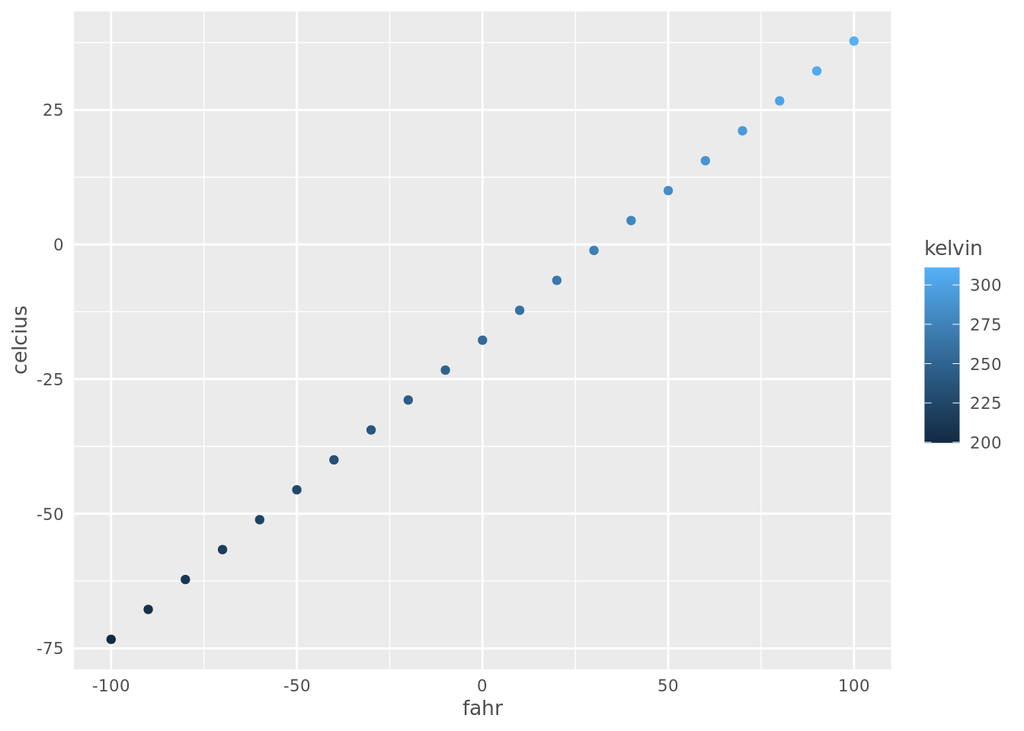

```r
themes_plot <- function(base_size = 9){
  ggplot2::theme(
    axis.ticks = ggplot2::element_blank(),
    text = ggplot2::element_text(family = 'Helvetica', color = 'gray30', size = base_size)
  )

}

ggplot(temps_df, mapping = aes(x = fahr, y = celcius, color = kelvin)) +
  geom_point() +
  themes_plot(10)
```

Scatter plot pass in a dataframe 2 new parameters the point size and the font-size passing in the dataframe temps_df can use multiple variables or multiple arguments to customize

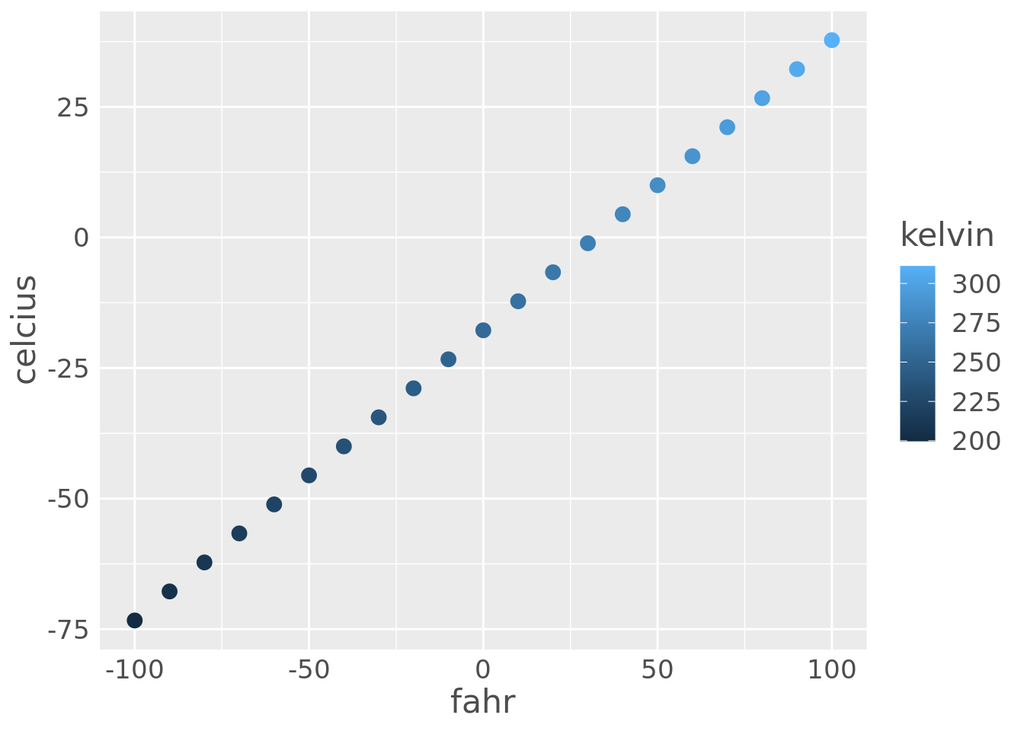

```r
scatterplot <- function(df, point_size = 2, font_size=9) {
  ggplot(df, mapping=aes(x=fahr, y=celcius, color=kelvin)) +
    geom_point(size=point_size) +
    themes_plot(font_size)
}

scatterplot(temps_df, point_size = 3, font_size = 16)
```

## Packages

What happens when you want to write a function that you want to use ALL the time? Packages! [1] You can create a separate .R file and then use the source command to run in the environment you’re in But with [1] you’d need a path so it’s not entirely portable [2] 2 mechanisms to distribute: upload to GitHub or distribute package through cran (submit to cran and then anyone can get it)